# Practical Machine Learning Course Project

Bill Ostaski

March 8, 2018

## Overview

This project involves creating predictive models using data from the Weight Lifting Exercises Dataset, which can be found at the Human Activity Recognition (HAR) Project (http://groupware.les.inf.puc-rio.br/har). Six young health participants were asked to perform one set of 10 repetitions of the Unilateral Dumbbell Biceps Curl in five different fashions: exactly according to the specification (Class A), throwing the elbows to the front (Class B), lifting the dumbbell only halfway (Class C), lowering the dumbbell only halfway (Class D) and throwing the hips to the front (Class E). The actual study and methodology can be found at: http://groupware.les.inf.puc-rio.br/public/papers/2013.Velloso.QAR-WLE.pdf

## Question

Can the 5 different fashions, Classes A through E, be predicted accurately through predictive models?

## Input Data

We were provided training and testing data sets gathered from accelerometers on the belt, forearm, arm and dumbell of the participants in a machine learning algorithm.

```r
# download and read in the data sets
trainURL <- "https://d396qusza40orc.cloudfront.net/predmachlearn/pml-training.csv"
testURL <- "https://d396qusza40orc.cloudfront.net/predmachlearn/pml-testing.csv"
download.file(url=trainURL, destfile="pml-training.csv")
download.file(url=testURL, destfile="pml-testing.csv")

# noticed many "#DIV/0!" strings in pml-training.csv
trainDF <- read.csv("pml-training.csv", na.strings=c("NA","#DIV/0!",""))
testDF <- read.csv("pml-testing.csv", na.strings=c("NA",""))

# verifying column names are identical in trainDF and testDF (except classe in trainDF)
# the "classe" variable in the training set is the outcome we want to predict
all.equal(colnames(trainDF)[1:length(colnames(trainDF))-1],colnames(testDF)[1:length(colnames(trainDF))-1])
```

```
## [1] TRUE
```

## Features

Tranforming the data to only include variables needed to build the models (removing variables with a lot of NAs, those that do not pertain to accelerometer measurements and variables with near zero variance)

```r
dim(trainDF); dim(testDF)
```

```
## [1] 19622   160
```

```
## [1]  20 160
```

```r
# there are a lot of columns with NAs, so let's remove them
trainDF <- trainDF[, colSums(is.na(trainDF)) == 0]
testDF <- testDF[, colSums(is.na(testDF)) == 0]

# let's also remove columns that do not pertain to accelerometer measurements
classe <- trainDF$classe # saving for later
trainRM <- grepl("^X|timestamp|window", names(trainDF))
trainDF <- trainDF[, !trainRM]
trainDF <- trainDF[, sapply(trainDF, is.numeric)]
trainDF$classe <- classe

testRM <- grepl("^X|timestamp|window", names(testDF))
testDF <- testDF[, !testRM]
testDF <- testDF[, sapply(testDF, is.numeric)]

dim(trainDF); dim(testDF)
```

```
## [1] 19622    53
```

```
## [1] 20 53
```

```r
all.equal(colnames(trainDF)[1:length(colnames(trainDF))-1], colnames(testDF)[1:length(colnames(trainDF))-1])
```

```
## [1] TRUE
```

```r
# checking for variables that have less than 10% variability
library(caret)
nearZeroVar(trainDF, saveMetrics=TRUE)
```

```
##                      freqRatio percentUnique zeroVar   nzv
## roll_belt             1.101904     6.7781062   FALSE FALSE
## pitch_belt            1.036082     9.3772296   FALSE FALSE
## yaw_belt              1.058480     9.9734991   FALSE FALSE
## total_accel_belt      1.063160     0.1477933   FALSE FALSE
## gyros_belt_x          1.058651     0.7134849   FALSE FALSE
## gyros_belt_y          1.144000     0.3516461   FALSE FALSE
## gyros_belt_z          1.066214     0.8612782   FALSE FALSE
## accel_belt_x          1.055412     0.8357966   FALSE FALSE
## accel_belt_y          1.113725     0.7287738   FALSE FALSE
## accel_belt_z          1.078767     1.5237998   FALSE FALSE
## magnet_belt_x         1.090141     1.6664968   FALSE FALSE
## magnet_belt_y         1.099688     1.5187035   FALSE FALSE
## magnet_belt_z         1.006369     2.3290184   FALSE FALSE
## roll_arm             52.338462    13.5256345   FALSE FALSE
## pitch_arm            87.256410    15.7323412   FALSE FALSE
## yaw_arm              33.029126    14.6570176   FALSE FALSE
## total_accel_arm       1.024526     0.3363572   FALSE FALSE
## gyros_arm_x           1.015504     3.2769341   FALSE FALSE
## gyros_arm_y           1.454369     1.9162165   FALSE FALSE
## gyros_arm_z           1.110687     1.2638875   FALSE FALSE
## accel_arm_x           1.017341     3.9598410   FALSE FALSE
## accel_arm_y           1.140187     2.7367241   FALSE FALSE
## accel_arm_z           1.128000     4.0362858   FALSE FALSE
## magnet_arm_x          1.000000     6.8239731   FALSE FALSE
## magnet_arm_y          1.056818     4.4439914   FALSE FALSE
## magnet_arm_z          1.036364     6.4468454   FALSE FALSE
## roll_dumbbell         1.022388    84.2065029   FALSE FALSE
## pitch_dumbbell        2.277372    81.7449801   FALSE FALSE
## yaw_dumbbell          1.132231    83.4828254   FALSE FALSE
## total_accel_dumbbell  1.072634     0.2191418   FALSE FALSE
## gyros_dumbbell_x      1.003268     1.2282132   FALSE FALSE
## gyros_dumbbell_y      1.264957     1.4167771   FALSE FALSE
## gyros_dumbbell_z      1.060100     1.0498420   FALSE FALSE
## accel_dumbbell_x      1.018018     2.1659362   FALSE FALSE
## accel_dumbbell_y      1.053061     2.3748853   FALSE FALSE
## accel_dumbbell_z      1.133333     2.0894914   FALSE FALSE
## magnet_dumbbell_x     1.098266     5.7486495   FALSE FALSE
## magnet_dumbbell_y     1.197740     4.3012945   FALSE FALSE
## magnet_dumbbell_z     1.020833     3.4451126   FALSE FALSE
## roll_forearm         11.589286    11.0895933   FALSE FALSE
## pitch_forearm        65.983051    14.8557741   FALSE FALSE
## yaw_forearm          15.322835    10.1467740   FALSE FALSE
## total_accel_forearm   1.128928     0.3567424   FALSE FALSE
## gyros_forearm_x       1.059273     1.5187035   FALSE FALSE
## gyros_forearm_y       1.036554     3.7763735   FALSE FALSE
## gyros_forearm_z       1.122917     1.5645704   FALSE FALSE
## accel_forearm_x       1.126437     4.0464784   FALSE FALSE
## accel_forearm_y       1.059406     5.1116094   FALSE FALSE
## accel_forearm_z       1.006250     2.9558659   FALSE FALSE
## magnet_forearm_x      1.012346     7.7667924   FALSE FALSE
## magnet_forearm_y      1.246914     9.5403119   FALSE FALSE
## magnet_forearm_z      1.000000     8.5771073   FALSE FALSE
## classe                1.469581     0.0254816   FALSE FALSE
```

Since the nzv values are all FALSE, there is no need to remove any variables.

## Algorithm

```r
# splitting the training data frame into 2 sets: train (70%) and test (30%)
set.seed(333)
inTrain <- createDataPartition(trainDF$classe, p = 0.7, list=FALSE)
train <- trainDF[inTrain,]
test <- trainDF[-inTrain,]

dim(train); dim(test)
```

```
## [1] 13737    53
```

```
## [1] 5885   53
```

```r
# using 3 algorithm models: gradient boosting, classification and regression trees and random forest
# creating a 5-fold cross validation parameter for trControl
crossVal <- trainControl(method='cv', number = 5)
```

```r
modGBM <- train(classe ~ ., data=train, trControl=crossVal, method='gbm')

modCART <- train(classe ~ ., data=train, trControl=crossVal, method='rpart')

modRF <- train(classe ~ ., data=train, trControl=crossVal, method='rf', ntree=250)
```

## Evaluation

```r
# checking these models' performance
predGBM <- predict(modGBM, newdata=test)
cmGBM <- confusionMatrix(predGBM, test$classe)

predCART <- predict(modCART, newdata=test)
cmCART <- confusionMatrix(predCART, test$classe)

predRF <- predict(modRF, newdata=test)
cmRF <- confusionMatrix(predRF, test$classe)

accuracy <- data.frame(Model = c('GBM', 'CART', 'RF'),
                       Accuracy = rbind(cmGBM$overall[1], cmCART$overall[1], cmRF$overall[1])
                      )
accuracy
```

```
##   Model  Accuracy
## 1   GBM 0.9597281
## 2  CART 0.4897196
## 3    RF 0.9942226
```

```r
# as we can see, the random forest model is the most accurate with an expected out of sample error of
# .6% (1 - .994 = 0.006 * 100) and the gradient boosting model a close second
# checking the confusion matrix for the random forest model
cmRF
```

```
## Confusion Matrix and Statistics
##
##           Reference
## Prediction    A    B    C    D    E
##          A 1674    3    0    0    0
##          B    0 1136    6    0    0
##          C    0    0 1018   18    0
##          D    0    0    2  946    5
##          E    0    0    0    0 1077
##
## Overall Statistics
##
##                Accuracy : 0.9942
##                  95% CI : (0.9919, 0.996)
##     No Information Rate : 0.2845
##     P-Value [Acc > NIR] : < 2.2e-16
##
##                   Kappa : 0.9927
##  Mcnemar's Test P-Value : NA
##
## Statistics by Class:
##
##                      Class: A Class: B Class: C Class: D Class: E
## Sensitivity            1.0000   0.9974   0.9922   0.9813   0.9954
## Specificity            0.9993   0.9987   0.9963   0.9986   1.0000
## Pos Pred Value         0.9982   0.9947   0.9826   0.9927   1.0000
## Neg Pred Value         1.0000   0.9994   0.9984   0.9964   0.9990
## Prevalence             0.2845   0.1935   0.1743   0.1638   0.1839
## Detection Rate         0.2845   0.1930   0.1730   0.1607   0.1830
## Detection Prevalence   0.2850   0.1941   0.1760   0.1619   0.1830
## Balanced Accuracy      0.9996   0.9981   0.9942   0.9900   0.9977
```

```r
# so let's use the random forest model on testDF
predTestDF <- predict(modRF, newdata=testDF)
resultsTestDF <- data.frame(problem_id=testDF$problem_id, predicted=predTestDF)
resultsTestDF
```

```
##    problem_id predicted
## 1           1         B
## 2           2         A
## 3           3         B
## 4           4         A
## 5           5         A
## 6           6         E
## 7           7         D
## 8           8         B
## 9           9         A
## 10         10         A
## 11         11         B
## 12         12         C
## 13         13         B
## 14         14         A
## 15         15         E
## 16         16         E
## 17         17         A
## 18         18         B
## 19         19         B
## 20         20         B
```

## Figures

Correlation Matrix Visualization

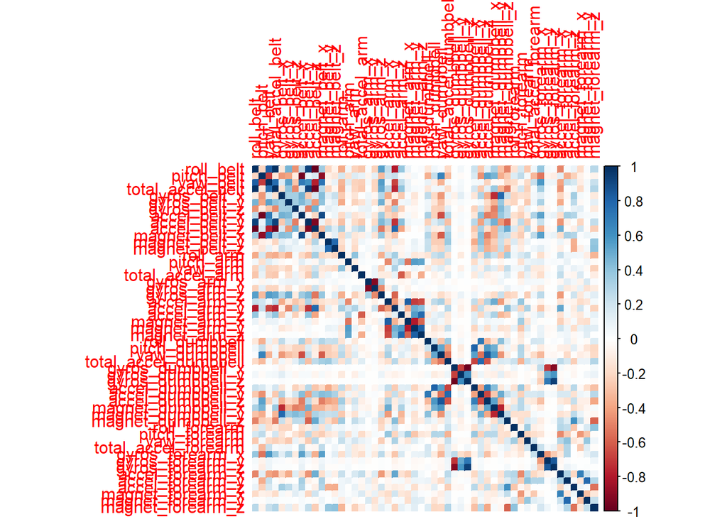

```r
library(corrplot)
corrPlot <- cor(trainDF[, -length(names(trainDF))])
corrplot(corrPlot, method="color")
```

Decision Tree Visualization

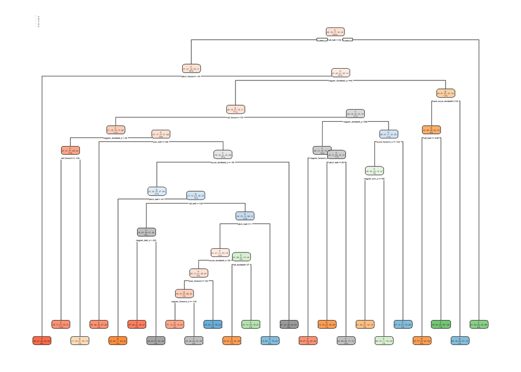

```r
library(rpart.plot)
treeModel <- rpart(classe ~ ., data=trainDF, method="class")
rpart.plot(treeModel)
```